# How has the Brazilian Amazon been constructed as a problem: presidential speeches and transnational politics since 1985

Henrique Sposito and Livio Silva-Muller

October 2022

*We need to protect the Amazon from foreign interests.*

*We need to exploit the Amazon’s natural resources.*

*We need to provide better living standards for the people in the Amazon.*

*We need to preserve the Amazon as a standing ecosystem.*

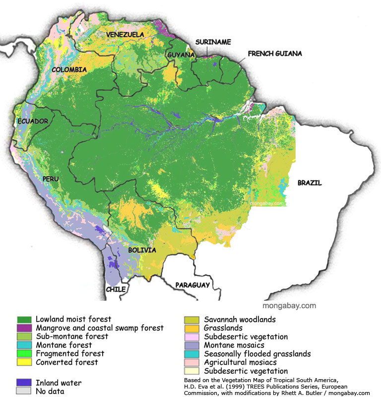

The Amazon Forest

# Question

*How the Brazilian Amazon has been constructed as a problem in transnational presidential speeches since 1985?*

# Data and methods

1-) Dataset containing all 6130 official speeches by presidents since 1985.

3-) Location of each speech.

4-) Hand-coding and supervised machine learning.

- Can you think of some limitations with this approach?

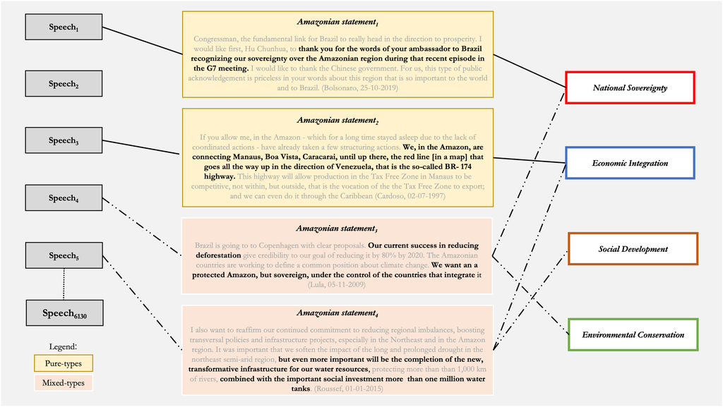

Operationalization of problem-constructions

```r
summary(ama)
```

```
##        ID        president              year         party
##  Min.   :1001   Length:1895        Min.   :1985   Length:1895
##  1st Qu.:1289   Class :character   1st Qu.:1996   Class :character
##  Median :1522   Mode  :character   Median :2003   Mode  :character
##  Mean   :1522                      Mean   :2003
##  3rd Qu.:1772                      3rd Qu.:2009
##  Max.   :2000                      Max.   :2021
##
##    location          mixed_type          hand_coded         other
##  Length:1895        Length:1895        Min.   :0.0000   Min.   :0.0000
##  Class :character   Class :character   1st Qu.:0.0000   1st Qu.:0.0000
##  Mode  :character   Mode  :character   Median :0.0000   Median :0.0000
##                                        Mean   :0.4902   Mean   :0.2106
##                                        3rd Qu.:1.0000   3rd Qu.:0.0000
##                                        Max.   :1.0000   Max.   :1.0000
##
##                location_cat      AAI           km_to_manaus      def_year
##  International       :165   Min.   :   1.65   Min.   :    0   Min.   : 4.571
##  Amazonian States    :533   1st Qu.:   4.52   1st Qu.:    0   1st Qu.:10.129
##  Amazonian Countries :153   Median :   6.41   Median : 1934   Median :14.286
##  Brasilia            :597   Mean   : 239.93   Mean   : 1950   Mean   :15.366
##  Non Amazonian States:444   3rd Qu.:  12.53   3rd Qu.: 2675   3rd Qu.:18.226
##  NA's                :  3   Max.   :2477.15   Max.   :15979   Max.   :29.059
##
##       area                                   mx_cat    election_year
##  Min.   : 4571   Pure Economic Integration      :465   Min.   :0.000
##  1st Qu.:10129   Other                          :399   1st Qu.:0.000
##  Median :14286   Pure Environmental Conservation:275   Median :0.000
##  Mean   :15366   Pure Social Development        :205   Mean   :0.258
##  3rd Qu.:18226   Economic Conservation          :130   3rd Qu.:1.000
##  Max.   :29059   Pure National Sovereignty      :105   Max.   :1.000
##                  (Other)                        :316
```

```r
# library(skimr)
# skimr::skim(ama)
```

# When Brazilian presidents speak about conservation in the context of the Amazon, where are they?

## A simple logistic regression

Why do we use a logistic model and not a linear one [here](https://stackoverflow.com/questions/12146914/what-is-the-difference-between-linear-regression-and-logistic-regression)?

```r
ama_model <- filter(ama, location_cat != "Non Identified",
                        mx_cat != "Other Mixed-types") %>%
  mutate(con_vs_all = ifelse(mx_cat == "Pure Environmental Conservation", 1, 0),
         EI_vs_all = ifelse(mx_cat == "Pure Economic Integration", 1, 0),
         SD_vs_all = ifelse(mx_cat == "Pure Social Development", 1, 0),
         sov_vs_all = ifelse(mx_cat == "Pure National Sovereignty", 1, 0))
# model
model_logit_con <- glm(con_vs_all ~ km_to_manaus + election_year + def_year + AAI,
                   family=binomial(link = "logit"), data = ama_model)
summary(model_logit_con)
```

```
##
## Call:
## glm(formula = con_vs_all ~ km_to_manaus + election_year + def_year +
##     AAI, family = binomial(link = "logit"), data = ama_model)
##
## Deviance Residuals:
##     Min       1Q   Median       3Q      Max
## -1.3118  -0.5825  -0.5130  -0.4377   2.3245
##
## Coefficients:
##                  Estimate  Std. Error z value             Pr(>|z|)
## (Intercept)   -1.71845866  0.19066729  -9.013 < 0.0000000000000002 ***
## km_to_manaus   0.00011555  0.00002145   5.386         0.0000000719 ***
## election_year  0.28790781  0.15665954   1.838             0.066093 .
## def_year      -0.03173895  0.01129821  -2.809             0.004966 **
## AAI            0.00038679  0.00010404   3.718             0.000201 ***
## ---
## Signif. codes:  0 '***' 0.001 '**' 0.01 '*' 0.05 '.' 0.1 ' ' 1
##
## (Dispersion parameter for binomial family taken to be 1)
##
##     Null deviance: 1549.3  on 1841  degrees of freedom
## Residual deviance: 1497.3  on 1837  degrees of freedom
## AIC: 1507.3
##
## Number of Fisher Scoring iterations: 4
```

*[Estimates are in log odds… But what are log-odds?](https://towardsdatascience.com/https-towardsdatascience-com-what-and-why-of-log-odds-64ba988bf704)*

*[Need an easy publication table? No worries!](https://rpubs.com/omerorsun/week3_stargazer)*

```r
stargazer::stargazer(model_logit_con, header = FALSE)
```

[output not shown]

## What about [time effects?](https://www.researchgate.net/post/Which_should_I_choose_Pooled_OLS_FEM_or_REM)

```r
pooled_ols <- plm::plm(con_vs_all ~ km_to_manaus + election_year + def_year + AAI,
                       data = ama_model, model = "pooling", index = c("year"))
summary(pooled_ols)
```

```
## Pooling Model
##
## Call:
## plm::plm(formula = con_vs_all ~ km_to_manaus + election_year +
##     def_year + AAI, data = ama_model, model = "pooling", index = c("year"))
##
## Unbalanced Panel: n = 37, T = 1-138, N = 1842
##
## Residuals:
##      Min.   1st Qu.    Median   3rd Qu.      Max.
## -0.470289 -0.158090 -0.126625 -0.082295  0.953062
##
## Coefficients:
##                    Estimate    Std. Error t-value       Pr(>|t|)
## (Intercept)    0.1429802958  0.0235559575  6.0698 0.000000001552 ***
## km_to_manaus   0.0000178431  0.0000032303  5.5237 0.000000037934 ***
## election_year  0.0359069945  0.0199552120  1.7994      0.0721228 .
## def_year      -0.0033476666  0.0012965902 -2.5819      0.0099026 **
## AAI            0.0000552053  0.0000146958  3.7565      0.0001776 ***
## ---
## Signif. codes:  0 '***' 0.001 '**' 0.01 '*' 0.05 '.' 0.1 ' ' 1
##
## Total Sum of Squares:    233.24
## Residual Sum of Squares: 226.09
## R-Squared:      0.030665
## Adj. R-Squared: 0.028555
## F-statistic: 14.5286 on 4 and 1837 DF, p-value: 0.00000000001099
```

```r
fixed <- plm::plm(con_vs_all ~ km_to_manaus + election_year + def_year + AAI,
                  data = ama_model, model = "within", index = c("year"))
summary(fixed)
```

```
## Oneway (individual) effect Within Model
##
## Call:
## plm::plm(formula = con_vs_all ~ km_to_manaus + election_year +
##     def_year + AAI, data = ama_model, model = "within", index = c("year"))
##
## Unbalanced Panel: n = 37, T = 1-138, N = 1842
##
## Residuals:
##      Min.   1st Qu.    Median   3rd Qu.      Max.
## -0.729676 -0.166751 -0.117960 -0.045981  0.970345
##
## Coefficients:
##                  Estimate   Std. Error t-value    Pr(>|t|)
## km_to_manaus 0.0000152831 0.0000033197  4.6037 0.000004441 ***
## ---
## Signif. codes:  0 '***' 0.001 '**' 0.01 '*' 0.05 '.' 0.1 ' ' 1
##
## Total Sum of Squares:    220.46
## Residual Sum of Squares: 217.9
## R-Squared:      0.011612
## Adj. R-Squared: -0.0086599
## F-statistic: 21.194 on 1 and 1804 DF, p-value: 0.0000044405
```

```r
# Not a good choice here, why? (tip: is this a balanced panel)

random <- plm::plm(con_vs_all ~ km_to_manaus + election_year + def_year + AAI,
                   data = ama_model, model = "random", index = c("president"))
summary(random)
```

```
## Oneway (individual) effect Random Effect Model
##    (Swamy-Arora's transformation)
##
## Call:
## plm::plm(formula = con_vs_all ~ km_to_manaus + election_year +
##     def_year + AAI, data = ama_model, model = "random", index = c("president"))
##
## Unbalanced Panel: n = 8, T = 22-589, N = 1842
##
## Effects:
##                    var  std.dev share
## idiosyncratic 0.122010 0.349300 0.952
## individual    0.006187 0.078657 0.048
## theta:
##    Min. 1st Qu.  Median    Mean 3rd Qu.    Max.
##  0.3125  0.7306  0.8171  0.7599  0.8200  0.8200
##
## Residuals:
##     Min.  1st Qu.   Median     Mean  3rd Qu.     Max.
## -0.54501 -0.16392 -0.12262 -0.00199 -0.08238  0.94123
##
## Coefficients:
##                    Estimate    Std. Error z-value      Pr(>|z|)
## (Intercept)    0.1301289997  0.0414516964  3.1393      0.001694 **
## km_to_manaus   0.0000177485  0.0000032289  5.4968 0.00000003867 ***
## election_year  0.0464289206  0.0211305356  2.1972      0.028003 *
## def_year      -0.0015416390  0.0017175629 -0.8976      0.369413
## AAI            0.0000460187  0.0000242763  1.8956      0.058010 .
## ---
## Signif. codes:  0 '***' 0.001 '**' 0.01 '*' 0.05 '.' 0.1 ' ' 1
##
## Total Sum of Squares:    230.69
## Residual Sum of Squares: 224.29
## R-Squared:      0.02777
## Adj. R-Squared: 0.025653
## Chisq: 41.8736 on 4 DF, p-value: 0.000000017719
```

```r
# Better, but not a good choice here, why? (tip: is this a balanced panel)
```

# Nominal outcome (dependent) variables, multinomial is the name of the game!

```r
library(nnet)
# model
model_multi <- nnet::multinom(mx_cat ~ location_cat + election_year + def_year + AAI,
                              data = ama_model, model = TRUE, trace = FALSE)
# summary statistics
summary(model_multi)
```

[output not shown]

But very hard to interpret as there are, often, multiple reference categories… Above the reference categories are Pure Economic Integration in international settings?!

# The Amazon multi-level game: talking to the people inside

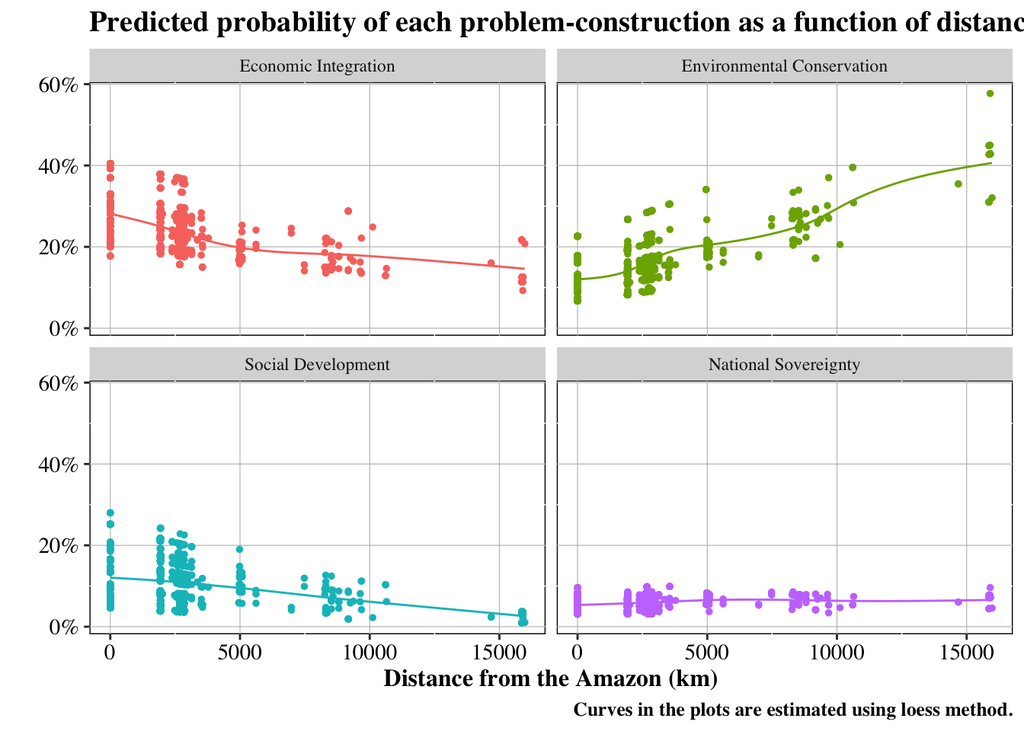

Logistic Regression predicted values

Can you see the relationship?

# The Amazon multi-level game: boasting policy outside

Why distances to Manaus by 1000km?